# Generalised Linear Models & Generalised Additive Models

02 June 2021

## Assumptions of Least Squares

1. The relationship between the response and the predictors is ~linear.
2. The residuals have a mean of zero.
3. **The residuals have constant variance (not heteroscedastic).**
4. The residuals are independent (uncorrelated).
5. **The residuals are normally distributed.**

Count data, binomial and proportion data do not have normally distributed errors

## Least squares

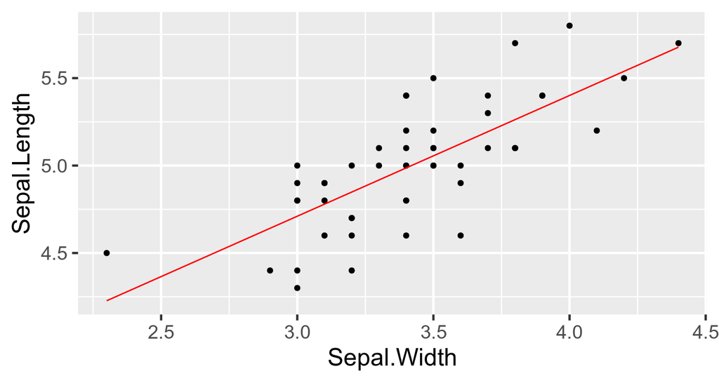

\(y_i = \beta_0 + \beta_1x_i + \epsilon_i\)

Find \(\beta_0\) and \(\beta_1\) that minimise \(\sum\epsilon ^ 2\)

## Maximum Likelihood

How likely are the data given the model? – choose coefficients to maximise likelihood

Residuals come from a distribution

Normal distribution: \(L(y;\mu,\sigma) = \frac{1}{\sigma \sqrt {2\pi } }e^{-\frac{(x - \mu)^2} {{2\sigma ^2 }}}\)

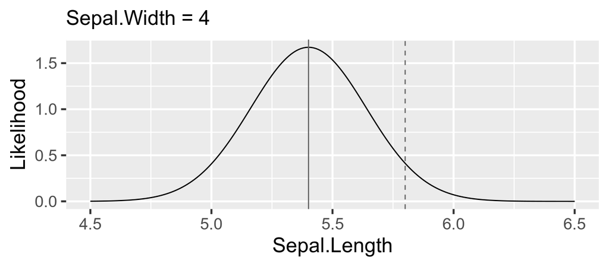

## Maximum Likelihood

For each observation find the likelihood

Find the product of the likelihoods (fails)

Find the sum of the log-likelihoods

\(\sum{(IL(y;μ,σ))} = {log}(\prod{L(y;μ,σ)})\)

Get model with maximum log-likelihood

Deviance is a measure of goodness-of-fit (equivalent to \(\sum{\epsilon ^2}\))

## Generalised Linear Model (GLM)

- Fitted with Maximum likelihood
- Suitable for various distributions
- Variance function
- Link function transforms response
- Linear predictor

\(y_i = β_0~ + β_1x_i + ε_i\)

\(g(E(y_i)) = β_0 + β_1x_i\)

## Distributions & links (E(y) = μ)

**Normal (gaussian)**

- y continuous
- All values
- \(\mu = E(y_i) = β_0 + β_1x_i\)
- \(var(y) = σ^2\)

**Poisson**

- Discrete
- Counts
- \(log(\mu) = β_0 + β_1x_i\)
- \(var(y) = \mu\)

**Binomial**

- Success/failure
- \(log(\frac{\mu}{1 - \mu}) = β_0 + β_1x_i\)
- \(var(y) = n\mu(1 - μ)\)

## Binomial distribution

Success = 1 & Failure = 0

n = trials

- number of Successes + Failures in an experiment.
- Special case n = 1 – Bernoulli trial

\(p\) = probability of success

\((1 - p)\) = probability of failure

\(μ = np\)

\(var(y) = np(1 - p)\)

**Suggest some types of data that you would expect to follow a binomial distribution**

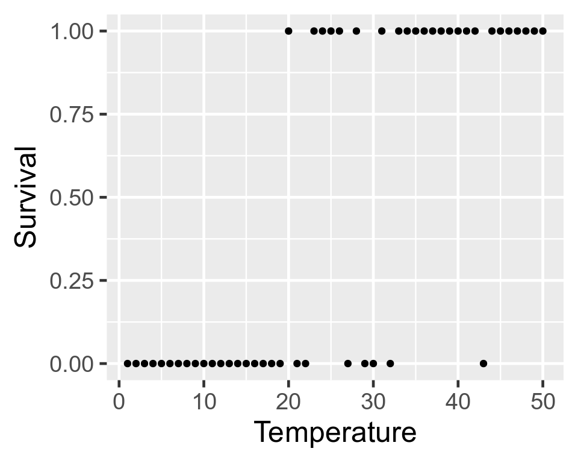

Use logistic link:

- \(log(\frac{p}{1 - p}) = \beta_0~ + \beta_1x_i\)
- \(p = \frac{exp(β_0 + β_1x_i)} {1 + exp(β_0 + β_1x_i)}\)

Response = Survival (i.e. success)

Predictor = temperature

```r
fit_glm <- glm(surv ~ temp, data = surv, family = binomial)
```

y is

- vector of 0 & 1
- factor representing success and failure
- vector giving the proportion of successes if multiple trials are used. Weights should give number of trials
- two column matrix giving number of successes and failures

```r
 anova(fit_glm)
```

```
## Analysis of Deviance Table
##
## Model: binomial, link: logit
##
## Response: surv
##
## Terms added sequentially (first to last)
##
##
##      Df Deviance Resid. Df Resid. Dev
## NULL                    49     69.235
## temp  1    35.78        48     33.454
```

```r
summary(fit_glm)
```

```
##
## Call:
## glm(formula = surv ~ temp, family = binomial, data = surv)
##
## Deviance Residuals:
##     Min       1Q   Median       3Q      Max
## -2.5170  -0.4130  -0.1319   0.4535   1.7267
##
## Coefficients:
##             Estimate Std. Error z value Pr(>|z|)
## (Intercept) -5.02708    1.39940  -3.592 0.000328 ***
## temp         0.18957    0.05026   3.772 0.000162 ***
## ---
## Signif. codes:  0 '***' 0.001 '**' 0.01 '*' 0.05 '.' 0.1 ' ' 1
##
## (Dispersion parameter for binomial family taken to be 1)
##
##     Null deviance: 69.235  on 49  degrees of freedom
## Residual deviance: 33.454  on 48  degrees of freedom
## AIC: 37.454
##
## Number of Fisher Scoring iterations: 6
```

Response:

\(p = \frac{exp(β_0 + β_1x_i)} { 1 + exp(β_0 + β_1x_i)}\)

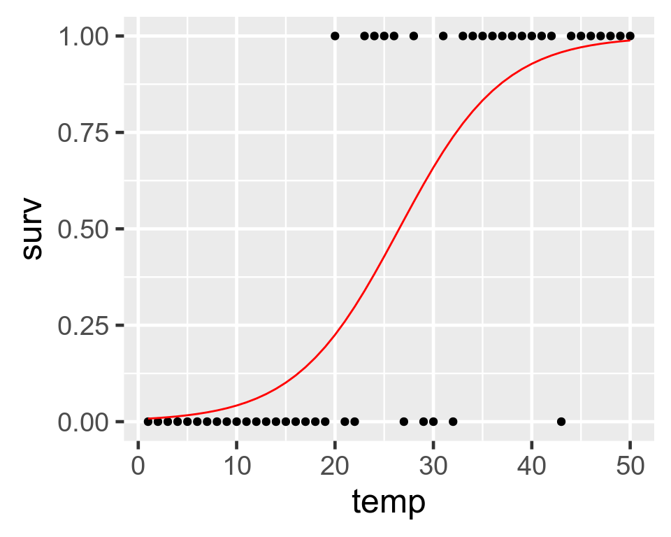

```r
ggplot(cbind(surv, fit = fitted(fit_glm)), aes(x = temp, y = surv)) +
  geom_point() +
  geom_line(aes(y = fit), colour = "red")
```

## Separation

Predictor perfectly separates zeroes and ones in response

```r
df <- data.frame(x = 1:20, y = rep(c(0, 1), each = 10))
mod <- glm(y ~ x, data = df, family = binomial)
```

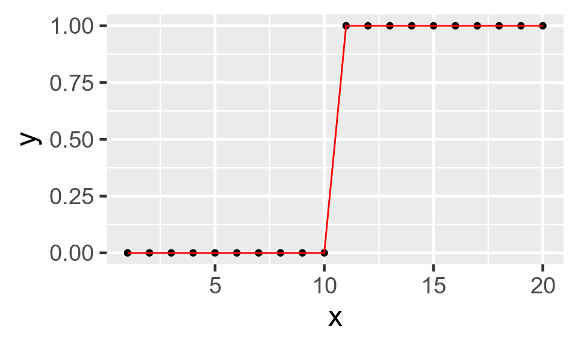

## Seperation

Very high coefficient

Very large uncertainty

- too many categorical predictors?
- maximum penalized likelihood package `brglm`
- Bayesian analysis `bayesglm` in `arm` package, rstan

## Poisson distribution

y = discrete (counts)

x = predictor

\(mean = \mu\)

\(var(y) = \mu\)

\(log(\mu) = β_0 + β_1x_i\)

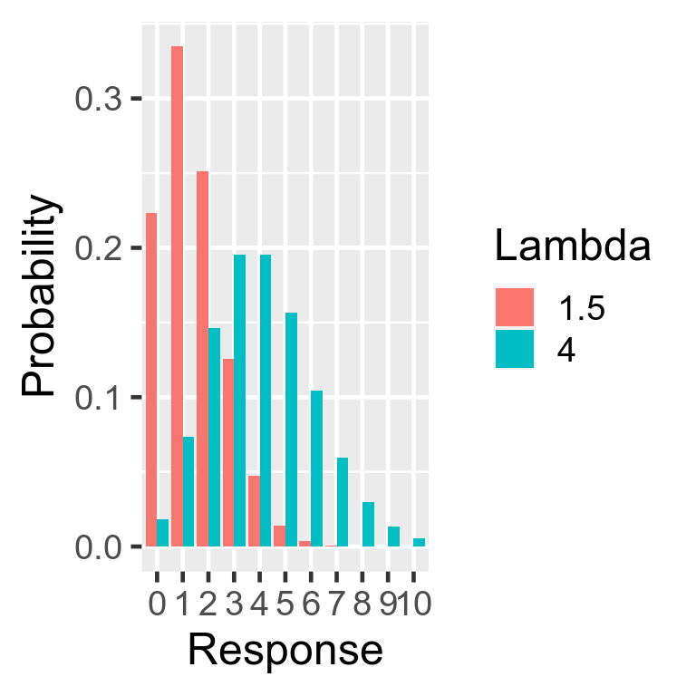

Shape depends on lambda

With large values of lambda, normal approximation is possible

**Suggest some data types that are Poisson distributed**

## Poisson example - Number of species vs. cover

```r
rich <- read.csv("practicals/data/sorich.csv")
str(rich)
```

```
## 'data.frame':    692 obs. of  3 variables:
##  $ cover   : num  0 0 0 0 0 0 0 0 0 0.2 ...
##  $ nsp     : int  2 1 1 3 1 3 2 1 0 2 ...
##  $ grasherb: int  0 0 0 0 0 0 0 0 0 0 ...
```

Predictor is cover

Response is number of species

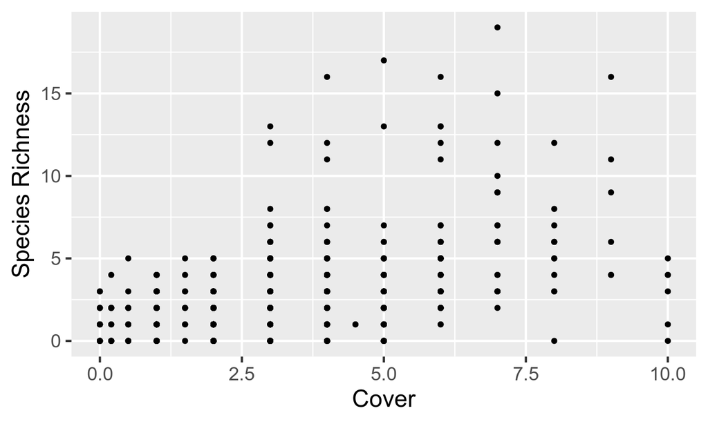

```r
ggplot(rich, aes(x = cover, y = nsp)) +
  geom_point() +
  labs(y = "Species Richness", x = "Cover")
```

```r
fit_glm <- glm(nsp ~ cover, data = rich, family = poisson)
anova(fit_glm, test = "Chisq")
```

```
## Analysis of Deviance Table
##
## Model: poisson, link: log
##
## Response: nsp
##
## Terms added sequentially (first to last)
##
##
##       Df Deviance Resid. Df Resid. Dev  Pr(>Chi)
## NULL                    691     1660.9
## cover  1   345.95       690     1315.0 < 2.2e-16 ***
## ---
## Signif. codes:  0 '***' 0.001 '**' 0.01 '*' 0.05 '.' 0.1 ' ' 1
```

```r
summary(fit_glm)
```

```
##
## Call:
## glm(formula = nsp ~ cover, family = poisson, data = rich)
##
## Deviance Residuals:
##     Min       1Q   Median       3Q      Max
## -4.2427  -1.1721  -0.1502   0.5258   5.5365
##
## Coefficients:
##             Estimate Std. Error z value Pr(>|z|)
## (Intercept)  0.17097    0.04931   3.467 0.000526 ***
## cover        0.20263    0.01037  19.541  < 2e-16 ***
## ---
## Signif. codes:  0 '***' 0.001 '**' 0.01 '*' 0.05 '.' 0.1 ' ' 1
##
## (Dispersion parameter for poisson family taken to be 1)
##
##     Null deviance: 1660.9  on 691  degrees of freedom
## Residual deviance: 1315.0  on 690  degrees of freedom
## AIC: 2869.1
##
## Number of Fisher Scoring iterations: 5
```

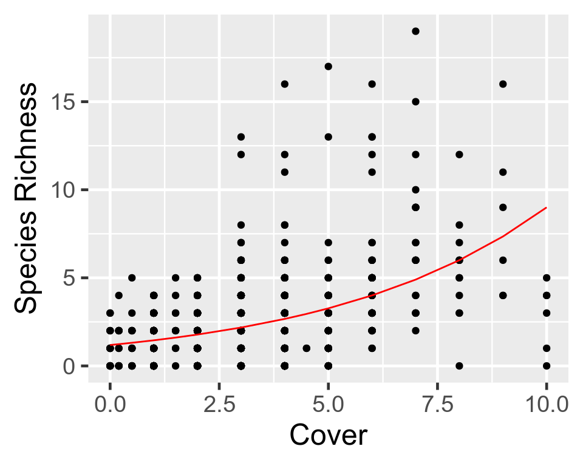

```r
ggplot(cbind(rich, fit = fitted(fit_glm)), aes(x = cover, y = nsp)) +
  geom_point() +
  geom_line(aes(y = fit), colour = "red") +
  labs(y = "Species Richness", x = "Cover")
```

log(μ) = β<sub>0</sub> + β<sub>1</sub>x<sub>i</sub>

## Overdispersion

Variance in Binomial and Poisson models is specified:

- Poisson \(var(y) = μ\)
- Binomial \(var(y) = nμ(1 - μ)\)

Real data can have more (or less) variance than this if not drawn from a pure Binomial or Poisson process.

- Overdispersed data has more variance than expected
- Overdispersion makes statistical tests too liberal. Increased risk of type I error.

## Detecting Overdispersion

Overdispersion if Residual deviance > residual df

```r
anova(fit_glm)
```

```
## Analysis of Deviance Table
##
## Model: poisson, link: log
##
## Response: nsp
##
## Terms added sequentially (first to last)
##
##
##       Df Deviance Resid. Df Resid. Dev
## NULL                    691     1660.9
## cover  1   345.95       690     1315.0
```

## Overdispersion

**What is it:**

- A dependency between observations
- Missing parameter(s)

**When:**

- Poisson
- Binomial if n >1  
  **What to do:**

Find missing parameters

Quasi-likelihood:

- quasipoisson
- quasibinomial

Negative binomial:

- Counts

Zero-inflated distributions

Hurdle models

## Quasi models

Poisson: \(var(y) = μ\)

Quasipoisson: \(var(y) = \phi\mu\)

Scale parameter \(\phi\) modifies relationship between mean and variance

```r
glm_fit1 <- glm(nsp ~ cover, data = rich, family = quasipoisson)
```

Fitted model will be the same

Confidence intervals will be wider

P values will be higher

No AIC for model selection. Quasi-AIC?

## Negative binomial

Negative binomial distribution:

Discrete probability distribution of the number of successes in a sequence of independent and identically distributed Bernoulli trials before a specified number of failures occurs.

Two parameters:

- p of Bernoulli trials
- r failures

Implemented in package `MASS`

```r
library("MASS")
fit_nb <- glm.nb(nsp ~ cover, data = rich, link = log)
```

Has AIC

## Zero-inflated models

Used to model count data that has an excess of zero counts.

- Excess zeros are generated by a separate process from the count values
- Excess zeros can be modleled independently.

Two component models

- Poisson/Negative binomial component
- Binomial component gives excess zeros

Fit with package `pscl` function `zeroinfl()`

## Predictions

By default, predictions are on linear-predictor scale

```r
fit_glm <- glm(nsp ~ cover, data = rich, family = poisson)
(pred <- predict(fit_glm, newdata = data.frame(cover = 10)))
```

```
##        1
## 2.197233
```

Transform with inverse of link to put on to response scale

Poisson uses log link

\(log(\mu) = \beta_0 + \beta_1x_i\)

Use exponential function

```r
exp(pred)
```

```
##        1
## 9.000076
```

Or ask for predictions on reponse scale

```r
(pred <- predict(fit_glm, newdata = data.frame(cover = 10), type = "response"))
```

```
##        1
## 9.000076
```

Link scale (linear predictor scale)

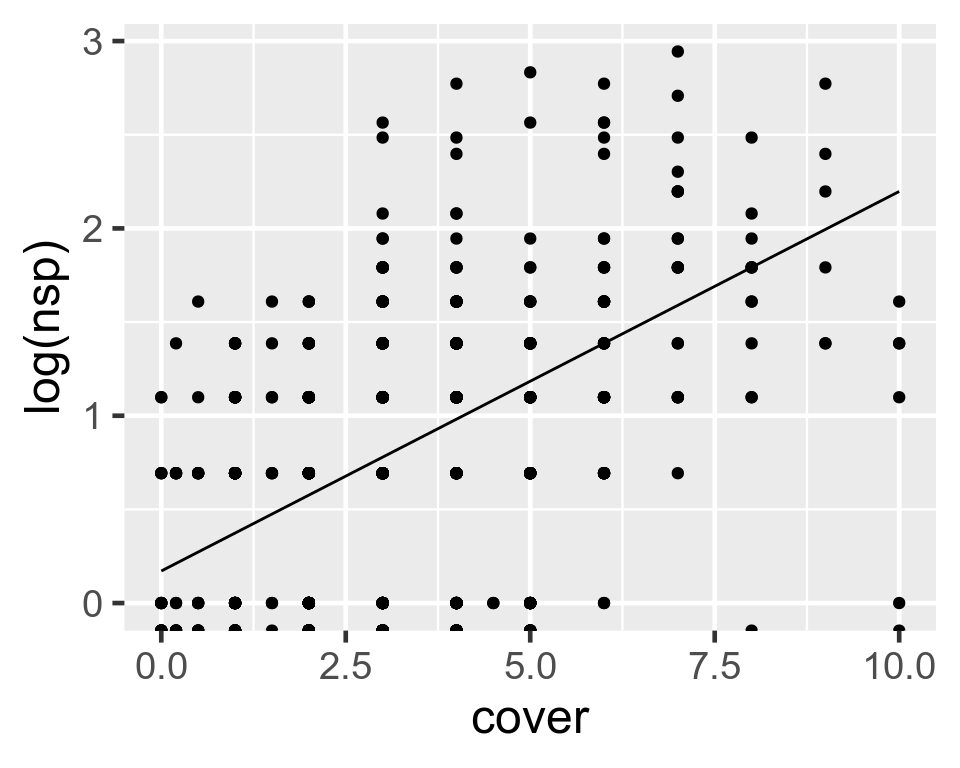

```r
ggplot(rich, aes(cover, log(nsp))) +
  geom_point() +
  geom_line(aes(x, y = fit), data  = data.frame(x = newD, fit = pred$fit), inherit.aes = FALSE)
```

Response scale (linear predictor scale)

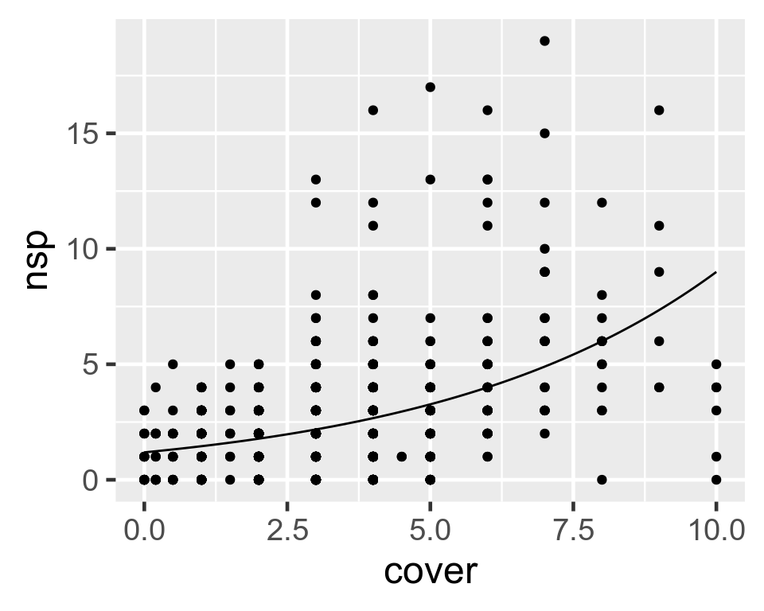

```r
ggplot(rich, aes(x = cover, y = nsp)) +
  geom_point() +
  geom_line(aes(x, y = fit), data  = data.frame(x = newD, fit = exp(pred$fit)), inherit.aes = FALSE)
```

## Confidence interval

Estimate \(\mu\) and SE on link scale {\(log(\mu)\) & SE}

Estimate confidence interval (\(\mu ± 2*SE\))

Use link-function to obtain values on ‘response scale’ {\(exp(\mu ± 2*SE)\)}

```r
(pred <- predict(fit_glm, newdata = data.frame(cover = 10), se.fit = TRUE))
```

```
## $fit
##        1
## 2.197233
##
## $se.fit
## [1] 0.06528709
##
## $residual.scale
## [1] 1
```

```r
#estimate
exp(pred$fit)
```

```
##        1
## 9.000076
```

```r
#upper 95%ci
exp(pred$fit + 1.96 * pred$se.fit)
```

```
##        1
## 10.22868
```

```r
#lower 95%ci
exp(pred$fit - 1.96 * pred$se.fit)
```

```
##        1
## 7.919043
```

Link scale (linear predictor scale)

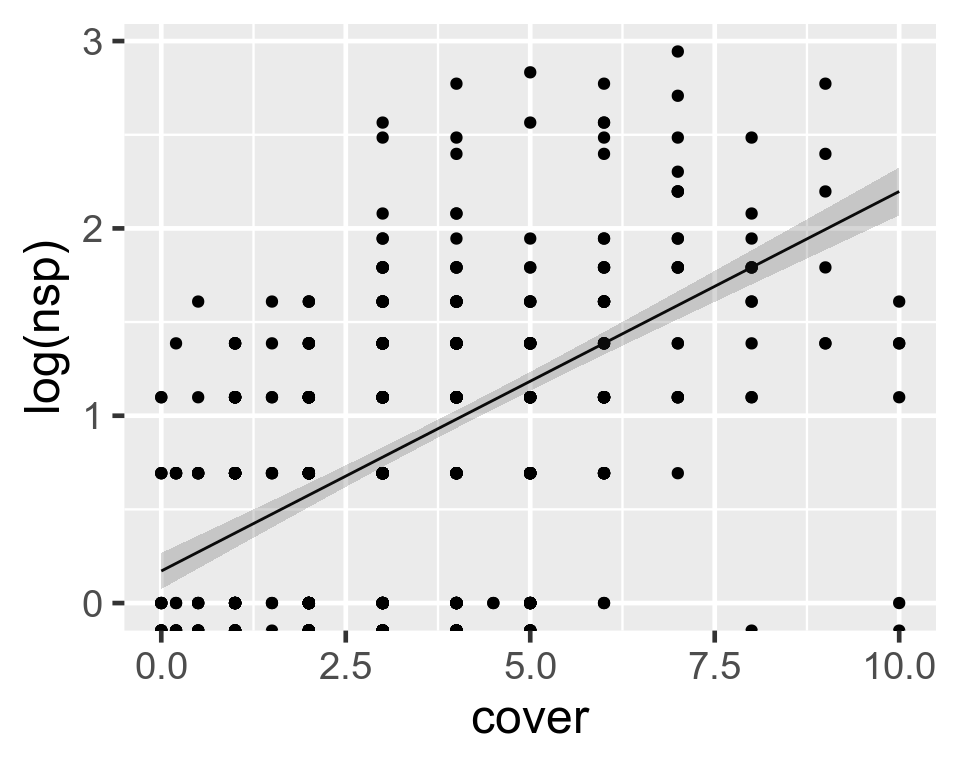

```r
ggplot(rich, aes(cover, log(nsp))) +
  geom_point() +
  geom_line(aes(x, y = fit), data  = data.frame(x = newD, fit = pred$fit), inherit.aes = FALSE) +
  geom_ribbon(aes(x, ymax = up, ymin = down), data  = data.frame(x = newD, up, down), inherit.aes = FALSE, alpha = 0.2)
```

Response scale (linear predictor scale)

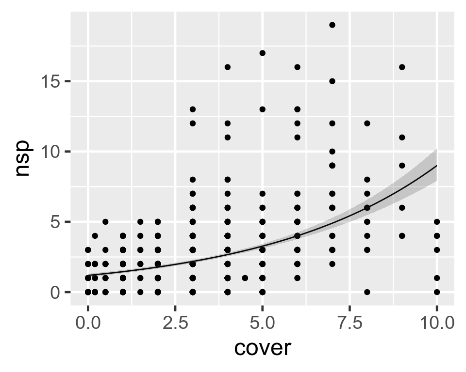

```r
ggplot(rich, aes(cover, nsp)) +
  geom_point() +
  geom_line(aes(x, y = fit), data  = data.frame(x = newD, fit = exp(pred$fit)), inherit.aes = FALSE) +
  geom_ribbon(aes(x, ymax = up, ymin = down), data  = data.frame(x = newD, up = exp(up), down = exp(down)), inherit.aes = FALSE, alpha = 0.2)
```

## Confidence intervals for Binomial

Analogous to calculation for Poisson

Use Logistic link function

\(log(\frac{p}{1-p})= β_0 + β_1x_i\)

\(p = \frac{exp(β_0 + β_1x_i)} {1 + exp(β_0 + β_1x_i)}\)

```r
fit.p <- predict(fit.glm, se.fit = TRUE, type = "link")
fit.mu <- with(fit.p, exp(fit) / (1 + exp(fit)))
fit.do <- with(fit.p, exp(fit - 1.96 * se.fit) / (1 + exp(fit - 1.96 * se.fit))
fit.up <- with(fit.p, exp(fit + 1.96 * se.fit) / (1 + exp(fit + 1.96 * se.fit))
```

## Distributions

Normal

- Continuous
- Constant variance
- All numbers

Poisson

- Discrete (counts)
- Variance = \(mu\)
- Positive numbers

Binomial

- Success / failure
- One outcome a trial
- many trials pr. observation
- variance = \(\mu(1 - \mu)\)

Gamma

- Continuous
- positive numbers
- variance \(\propto \mu ^ 2\)

Log normal

- `family = gaussian(link = "log")`

## Generalised additive models

Assume smooth response to predictor

Data-driven

Don’t know what reponse should be

Exploration of data

Can take any distribution and link function available for GLM

Smooth terms

- s()
- y ~ s(x)

Complexity of smooth terms estimated using Generalised cross-validation

Omit the smooth term and get a GLM!

lot more on GAMs at https://github.com/gavinsimpson/adelaide-2017/blob/master/02-tuesday/02-gams.pdf

Try the course on Generalised Additive Models in R at https://noamross.github.io/gams-in-r-course/

## GAM in R

```r
pot <- read.csv("practicals/data/pot.csv")
library(mgcv)
mod <- gam(potalp ~ s(alt), data = pot, family = binomial)
mod2 <- gam(potalp ~ alt + I(alt^2), data = pot, family = binomial)
anova(mod, mod2, test = "Chisq")
```

```
## Analysis of Deviance Table
##
## Model 1: potalp ~ s(alt)
## Model 2: potalp ~ alt + I(alt^2)
##   Resid. Df Resid. Dev      Df Deviance Pr(>Chi)
## 1    564.97     525.35
## 2    568.00     529.28 -3.0331  -3.9306   0.2737
```

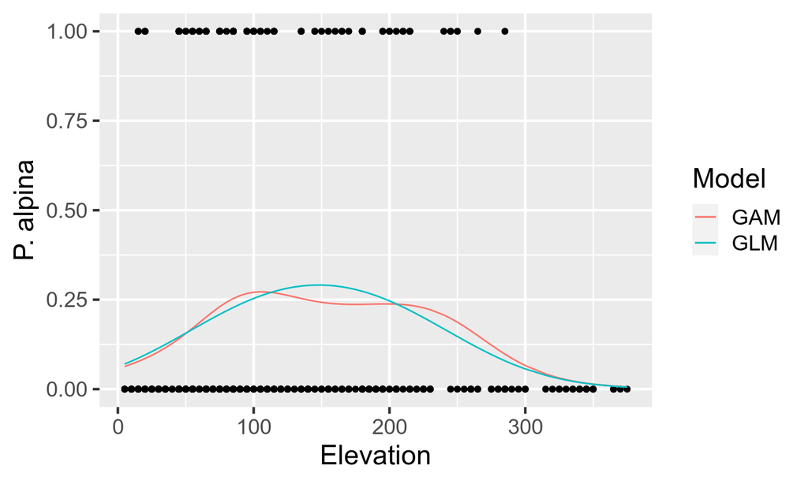

```r
ggplot(cbind(pot, fit.gam = fitted(mod), fit.glm = fitted(mod2)), aes(alt, potalp)) +
  geom_point() +
  geom_line(aes(y = fit.gam, colour = "GAM")) +
  geom_line(aes(y = fit.glm, colour = "GLM")) +
  labs(x = "Elevation", y = "P. alpina", colour = "Model")
```